# What’s wrong with my plot?

## Alternative to stacked bar charts

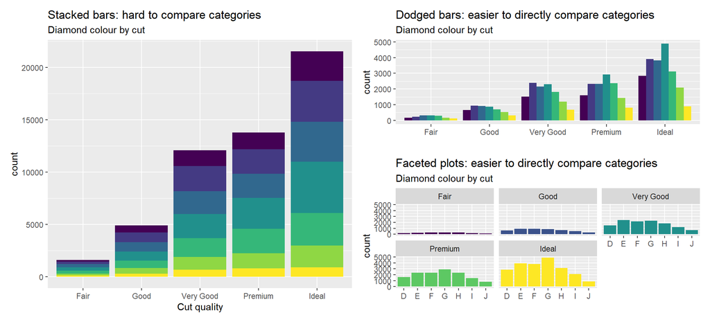

Stacked bar charts are a useful way to compare totals across groups. In the example below we can clearly see the differences in count between each cut quality, but if we want to compare a particular colour grade across the different cut quality groups it becomes much harder because each segment sits on a different baseline, making direct comparison difficult.

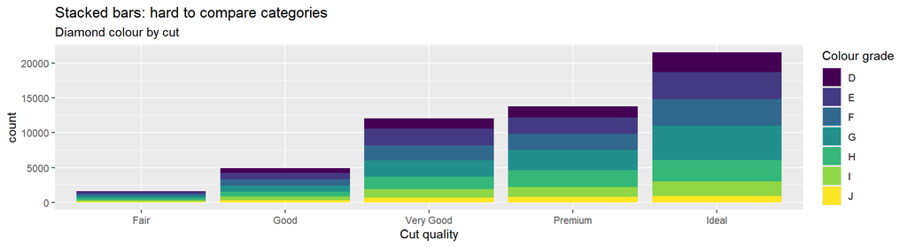

An alternative is to use a dodged bar chart. In the example below it is now much easier to compare a particular colour grade across the different cut quality groups, as each bar shares a common baseline. The choice between the two depends on what you want to emphasise, stacked charts are better for comparing totals, while dodged charts are better for comparing individual categories. In some cases, showing both side by side can be a useful way to give a more complete picture of the data.

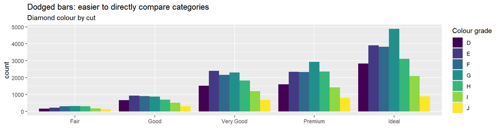

Another alternative is a faceted chart, where the data is split into separate panels — one per cut quality group. This makes it easy to compare the distribution of colour grades across each cut quality.

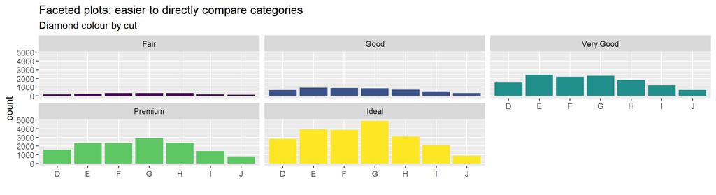

*Compiled for student use by Dr Philippa Wilkes. Methods reflect personal opinion only; the author has no affiliation with any of the resources mentioned. Last updated: June 2026.*